# DARE-1

Seulbi Lee, Havi Khurana, Janette Avelar

2024-01-26

### A. Data Management Tasks

```r
# convert enroll to percentage
dat <- dat %>%
    mutate(across(enroll_OTHER:enroll_WHITE, ~.x/enroll*100))
```

```r
# make flags for teacher_eval policy, class_remove policy, suspension policy
# make run time for time with respect to teacher_eval policy
# make interaction term for teacher_eval and run_time
# For states with no policy, the NAs to convert to 0
# For states with no teacher eval policy, run_time set to -1

dat <- dat |>
  mutate(eval = ifelse(school_year >= eval_year, 1, 0),
         class_remove = ifelse(school_year >= class_remove_year, 1, 0),
         suspension = ifelse(school_year >= suspension_year, 1, 0),
         run_time = school_year - eval_year,
         run_time = ifelse(is.na(eval_year), -1, run_time),
         across(eval:suspension, ~ifelse(is.na(.x),0, .x)),
         evalXyear = eval * run_time,
         FRPL_percent = FRPL_percent*100) #FRPL is in proportion
```

### B. Understanding the Data and Descriptive Statistics

```r
# summary(dat)
dat_complete <- dat[!is.na(dat$ODR_class) & !is.na(dat$ODR_objective) &
                    !is.na(dat$ODR_other) & !is.na(dat$ODR_subjective), ]
```

**B1.** Due to missingness in the implementation year variables, 14% of the observations for `run_time` and `evalXyear` are missing. This missingness concerns us slightly, as these variables are critical to the model. However, because they will be ignored when running the model, we did not remove the missing observations from the dataset and set their `run_time` to -1. The key type of missingness that we *are* concerned with are the missing observations for office disciplinary referrals (ODRs), since this is our outcome variable. Thus, we removed these 46 missing observations. Our enrollment variables, including race/ethnicity data, were also missing ~9% of all observations, but the missing observations overlapped with all missing observations for ODRs and were thus simultaneously removed.

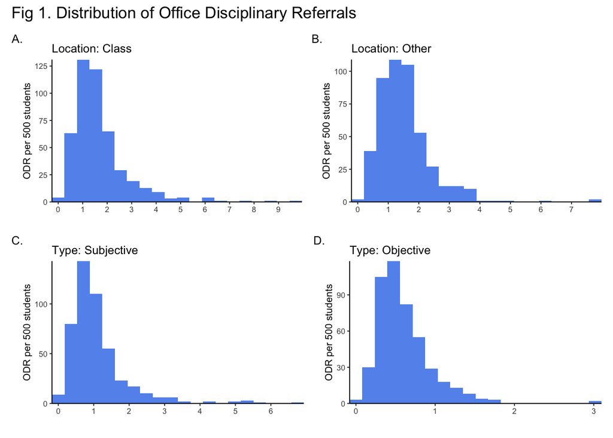

```r
viz_histogram <- function(outcome, plot_title){
    viz <- ggplot(dat_complete, aes({{outcome}})) +
    geom_histogram(bins = 20, fill = "cornflowerblue")+               scale_x_continuous(breaks = 0:10,
                       expand = c(0,0)) +
    scale_y_continuous(expand = c(0,0))+
    theme_classic(8)+
    labs(y = "ODR per 500 students",
         x= "",
         title = plot_title)

    return(viz)
}
viz_class <- viz_histogram(ODR_class, "Location: Class")
viz_objective <- viz_histogram(ODR_objective, "Type: Objective")
viz_other <- viz_histogram(ODR_other, "Location: Other")
viz_subjective <- viz_histogram(ODR_subjective, "Type: Subjective")

(viz_class + viz_other) / (viz_subjective + viz_objective) +
    plot_annotation(
        title = "Fig 1. Distribution of Office Disciplinary Referrals",
        tag_levels = 'A',
        tag_suffix = "."
    )
```

**B2.** The distribution for all referrals by location and type appears to be unimodal but exhibits a right skew. This pattern suggests that most state years have relatively few ODRs, and few state years have very high numbers. To address the skewed distribution, a log transformation or a Box-Cox transformation can be considered to handle skewed data to make the distribution more symmetrical.

**B3.** The analytical sample is drawn from public schools that were in states which implemented teacher evaluation policy during 2006-07 to 2017-18, those who used the Positive Behavior Implementation and Supports (PBIS) framework to track their students’ behavior using the School-Wide Information System (SWIS), and those who agreed to share their data for research. In the narrowest sense, the results of the analysis are generalizable to such public schools. In its widest sense, the results are generalizable to schools that have behavior interventions similar to PBIS and those who track their students’ behavior data.

In Table 1, we present the descriptive statistics of the demographic and outcome variables. On average, there are 21,897 students in a given state and year in our sample. About 54% of the students qualified for free and reduced price lunch. By racial and ethnic identities, 54% of the students identified as White followed by 18% identifying as Hispanic, 13% identifying as Black, and 5% students identified as Asian. A small percentage of students identified as American Indian/Alaskan Native and other ethnicities. 72% of the school-year observations had schools that successfully implemented PBIS. On average, 1.39 ODRs (1.33 ODRs) originated in classroom (other) settings per day per 500 students. The mean ODRs for subjective (objective) disciplinary behavior per day per 500 students was 0.87 (0.53). The mean of the sample characteristics are only slightly different from the ones reported in Liebowitz, Porter & Bragg (2022) with a magnitude difference of 2-3 percentage points. However, the standard deviations are remarkably smaller probably because our data is aggregated at state-year level. The means of the outcome variables is also only slightly different but the weighted standard deviations are smaller. We don’t anticipate much difference in the main results given the similarity in the mean of the variables.

```r
# create weighted columns
dat_summ <- dat_complete %>%
    group_by(school_year) %>%
    mutate(enroll_year = sum(enroll),
           across(c(FRPL_percent:ODR_objective), ~.x*enroll),
           across(c(FRPL_percent:ODR_objective), ~sum(.x, na.rm = T)/enroll_year)) %>%
    ungroup()


dat_summ <- dat_summ %>%
    # ordering columns
    select(FRPL_percent, enroll_AM, enroll_ASIAN, enroll_BLACK,
           enroll_HISP, enroll_WHITE, PBIS, ODR_class:ODR_objective) %>%
    # changing PBIS to percentage
    mutate(PBIS = PBIS*100) %>%
    summarize(across(everything(), ~paste0(round(mean(.x, na.rm = T),2),"\n(", round(sd(.x, na.rm = T),2), ")"))) %>%
    pivot_longer(
        cols = everything(),
        names_to = "chr",
        values_to = "desc"
    )

state_year <- round(mean(dat_complete$enroll),2)
year <- dat_complete %>% group_by(school_year) %>% summarize(total_enroll = sum(enroll))
year <- round(mean(year$total_enroll),2)
enroll_mean <- data_frame(
    chr = c("state-year", "year"),
    desc = c(as.character(state_year), as.character(year))
)

dat_summ <- rbind(enroll_mean, dat_summ)
dat_summ$chr <- c("Mean state-year enrollment",
                   "Mean year enrollment",
                   "% low-income (FRPL)",
                   "% Am. Indian/Alask. Native",
                   "% Asian",
                   "% Black",
                  "% Hispanic",
                   "% White",
                   "% state-year observations in which PBIS was successfully implements",
                   "Classroom ODR rate",
                   "Other location ODR rate",
                   "Subjective-Classroom ODR rate",
                   "Objectiv-Classroom ODR rate")

dat_summ %>%
    flextable() %>%
    set_header_labels(
  values = list(
    chr = "Variable",
    desc = "Mean (sd)")
) %>%
    add_header_lines("Table 1. Descriptive statistics of key variables") %>%
    align(1, 1, align = "left", "header") %>%
    add_footer_lines("Reported means and standard deviation are weighted by state and year.") %>%
    width(width = 2)
```

| Table 1. Descriptive statistics of key variables Variable | Table 1. Descriptive statistics of key variables Mean (sd) |
| --- | --- |
| Mean state-year enrollment | 21897.41 |
| Mean year enrollment | 857648.67 |
| % low-income (FRPL) | 54.53 (4.71) |
| % Am. Indian/Alask. Native | 1.14 (0.09) |
| % Asian | 4.65 (0.6) |
| % Black | 13.37 (2.05) |
| % Hispanic | 18.77 (5.17) |
| % White | 54.56 (1.93) |
| % state-year observations in which PBIS was successfully implements | 72.14 (44.9) |
| Classroom ODR rate | 1.39 (0.14) |
| Other location ODR rate | 1.33 (0.13) |
| Subjective-Classroom ODR rate | 0.87 (0.1) |
| Objectiv-Classroom ODR rate | 0.53 (0.05) |

Reported means and standard deviation are weighted by state and year.

**B4.** Figure 2 presents the mean ODRs plotted against time to teacher evaluation policy. The trend seems relatively flatter with little discontinuity at the 0 time-point. However, there does appear to be a small drop in the mean ODRs in year 2 and 3 after the policy implementation. Since teacher evaluation policy followed staggered implementations, there may only be a few states that are contributing to the 2- and 3-year post-policy averages. Therefore, we would like to plot average ODRs after controlling for state and year fixed effects. Here, we only plotted ODRs for states that implemented the policy as the time to policy evaluation isn’t defined for states that have not yet implemented the policy. Though, for the purpose of the analysis we set the run_time as -1 for these states, adding them to the average for the -1 time point would bias the point estimate.

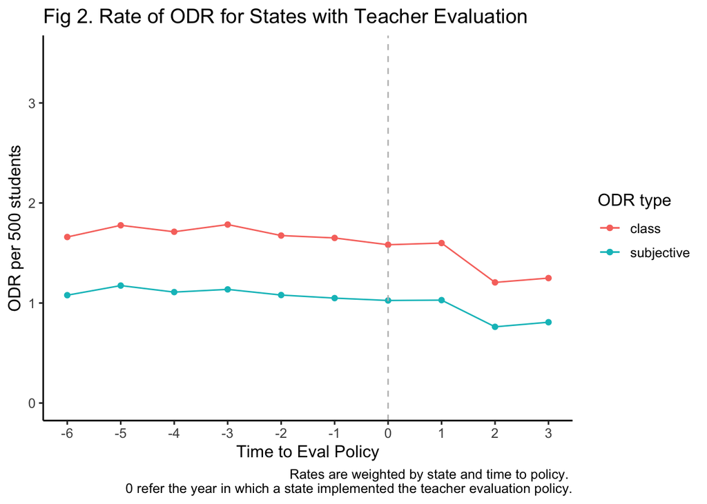

```r
dat_complete %>%
    # remove states that didn't implement teacher evaluation and restrict time
    filter(!is.na(eval_year), run_time %in% c(-6:3)) %>%
    # find state-run_time weighted averages
    group_by(run_time) %>%
    mutate(
        enroll_run_time = sum(enroll),
        odr_class = ODR_class*enroll,
        odr_class = sum(odr_class)/enroll_run_time,
        odr_sub = ODR_subjective*enroll,
        odr_sub = sum(odr_sub)/enroll_run_time
    ) %>%
    summarize(
        odr_class = mean(ODR_class, na.rm = T),
        odr_sub = mean(ODR_subjective, na.rm = T)
    ) %>%
    ggplot()+
    geom_point(aes(x = run_time, y = odr_class, color = "class")) +
    geom_line(aes(x = run_time, y = odr_class, color = "class")) +
    geom_point(aes(x = run_time, y = odr_sub, color = "subjective")) +
    geom_line(aes(x = run_time, y = odr_sub, color = "subjective")) +
    ylim(0,3.5) +
    scale_x_continuous(breaks = c(-6:3))+
    geom_vline(xintercept = 0, linetype = "dashed", color = "gray")+
    labs(x = "Time to Eval Policy",
         y = "ODR per 500 students",
         color = "ODR type",
         title = "Fig 2. Rate of ODR for States with Teacher Evaluation",
         caption = "Rates are weighted by state and time to policy. \n0 refer the year in which a state implemented the teacher evaluation policy.") +
    theme_classic(12)
```

### C. Replication and Extension

```r
model1 <- feols(ODR_class ~ eval | state_id + school_year, data = dat_complete, weights = dat_complete$enroll)

model2 <- feols(ODR_class ~ eval*run_time | state_id + school_year, data = dat_complete, weights = dat_complete$enroll)

# not significantly different from 0
# Keep models 2+3
# commented out vcov = ~ state_id^school_year as it was said "cells report estimates and associated standard errors clustered at the state level in parentheses." pg 21
modelsummary(list("Constant effect" = model1, "Linear effect" = model2),
          title = "Table 2: Comparison of Regression Models",
          coef_rename = c("eval" = "Teacher Evaluation",
                          "run_time" = "Time to policy"),
          gof_omit = "AIC|BIC|Log|RMSE|R2 .*",
          note = "Models are estimated with two-way fixed effect for state and year. No other covariates were used. Std. errors are clustered at state-level.",
          )
```

Table 2: Comparison of Regression Models

|  | Constant effect | Linear effect |
| --- | --- | --- |
| Teacher Evaluation | −0.060 | −0.023 |
|  | (0.058) | (0.043) |
| Time to policy |  | −0.029 |
|  |  | (0.023) |
| Teacher Evaluation:Time to policy |  | 0.044 |
|  |  | (0.032) |
| Num.Obs. | 470 | 470 |
| R2 | 0.825 | 0.827 |
| Std.Errors | by: state_id | by: state_id |
| FE: state_id | X | X |
| FE: school_year | X | X |

Models are estimated with two-way fixed effect for state and year. No other covariates were used. Std. errors are clustered at state-level.

Although the estimates are not exactly the same as the models in Liebowitz et al. (2022), both report the effects of teacher evaluation implementation closer to zero and confidently rule out certain ranges of moderating effects. To ensure the model specifications match those reported in the paper, we may conduct additional robustness checks to see how sensitive the results are to different model specifications or samples.

```r
mod_c21_class <- feols(ODR_class ~ eval + class_remove + suspension
                       | state_id + school_year,
                       vcov = ~state_id,
                       data = dat_complete,
                       weights = dat_complete$enroll)

#summary(mod_c21_class)

# robustness check - two-way standard error
mod_c22_class <- feols(ODR_class ~ eval
                       | state_id + school_year,
                       vcov = ~state_id + school_year,
                       data = dat_complete,
                       weights = dat_complete$enroll)

#summary(mod_c22_class)
modelsummary(list("Simultaneous policy" = mod_c21_class,
                  "Two-way clustered SE" = mod_c22_class),
             estimate = "{estimate} [{conf.low},{conf.high}]",
             statistic = NULL,
             coef_rename = c("eval" = "Teacher Evaluation",
                             "class_remove" = "Class removal policy",
                             "suspension" = "Suspension policy"),
             gof_omit = "AIC|BIC|Log|RMSE|R2 .*",
             title = "Table 3. Robustness Checks",
             notes = "Model estimates and 95% Confidence Intervals are presented.")
```

Table 3. Robustness Checks

|  | Simultaneous policy | Two-way clustered SE |
| --- | --- | --- |
| Teacher Evaluation | −0.073 [−0.186,0.040] | −0.060 [−0.172,0.053] |
| Class removal policy | 0.064 [−0.211,0.339] |  |
| Suspension policy | 0.079 [−0.043,0.201] |  |
| Num.Obs. | 470 | 470 |
| R2 | 0.827 | 0.825 |
| Std.Errors | by: state_id | by: state_id & school_year |
| FE: state_id | X | X |
| FE: school_year | X | X |

Model estimates and 95% Confidence Intervals are presented.

**C2.** We ran two robustness checks, which are presented in Table 3. If other discipline reforms were contemporaneous with teacher evaluation reforms, our estimates would be biased and incorrectly attribute the effect. When adding indicator variables to account for other reforms, such as suspension and class removal reforms, we find that other reforms don’t predict any changes in the rates of ODRs in class or moderate the effect of teacher evaluation. In our second test, we accounted for two-way clustered standard errors at the state and year levels. Since there is auto-correlation in the panel dataset, not choosing the correct structure to account for the variance can bias our estimates. When we used two-way clustered standard errors, however, our main result held.

**C3.** In line with the findings from the original study by Liebowitz, Porter, and Bragg (2022), our replication found no causal effects on the overall rate of Office Disciplinary Referrals (ODR) from the implementation of higher-stakes teacher evaluation. There was no evidence that higher-stakes teacher evaluation policies changed teacher behavior in response to students’ misbehavior, even when accounting for the introduction of potentially simultaneous discipline policy reforms or when altering our model specification to account for state-year clustering. Our null findings further support the conclusion that teacher evaluation alone does not improve classroom climate or reduce the rates of exclusionary discipline practices in schools.

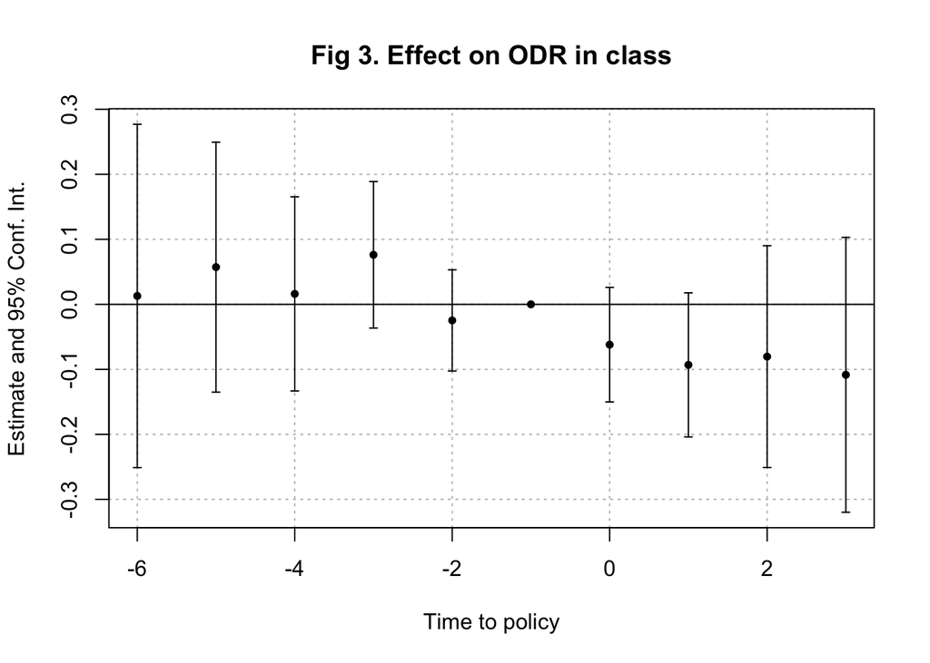

```r
dat_event <- dat_complete %>% filter(run_time %in% c(-6:3))
mod_c4 <- feols(ODR_class ~ i(run_time, ref = -1) |
                    state_id + school_year,
                vcov = ~state_id,
                weights = dat_event$enroll,
                data = dat_event)

# modelsummary(list("Event-study" = mod_c4),
#              gof_omit = "AIC|BIC|Log|R.*",
#              title = "Table 4. Event-study estimate",
#              notes = "Standard errors are clustered by state.")

iplot(mod_c4,
      main = "Fig 3. Effect on ODR in class",
      xlab = "Time to policy")
```

```r
mod_c5 <- feols(ODR_class ~ eval*PBIS |
                    state_id + school_year,
                vcov = ~state_id,
                weights = dat_complete$enroll,
                data = dat_complete)

modelsummary(list("Moderation by PBIS implementation" = mod_c5),
             estimate = "{estimate} [{conf.low},{conf.high}]",
             statistic = NULL,
             coef_rename = c("eval" = "Teacher Evaluation",
                             "PBIS" = "PBIS implementation fidelity",
                             "eval*PBIS" = "Teacher Evaluation*PBIS"),
             gof_omit = "AIC|BIC|Log|RMSE|R2 .*",
             title = "Table 4. Moderating Effect of PBIS implementation fidelity on ODRs",
             notes = "Model estimates and 95% Confidence Intervals are presented.")
```

Table 4. Moderating Effect of PBIS implementation fidelity on ODRs

|  | Moderation by PBIS implementation |
| --- | --- |
| Teacher Evaluation | −0.045 [−0.268,0.177] |
| PBIS implementation fidelity | −0.056 [−0.261,0.150] |
| Teacher Evaluation:PBIS implementation fidelity | 0.008 [−0.196,0.212] |
| Num.Obs. | 341 |
| R2 | 0.871 |
| Std.Errors | by: state_id |
| FE: state_id | X |
| FE: school_year | X |

Model estimates and 95% Confidence Intervals are presented.